# 1) Let X, Y, and Z be independent RVs with variances σX , σY , σZ . Let:

\begin{equation} U=Z−X \\ V=Z−Y \end{equation}

## Answer the following questions:

(a) Find Cov(U, V) and ρU,V

(b)If U=Z+X and V=Z+Y, do the values of Cov(U,V)and ρU,V computed inpart a) change? Explain.

(c) How does ρU,V change if σ^2_Z is much larger than σ^2_X or σ^2_Y?

(d) How does ρU,V change if σ^2_Z is much smaller than σ^2_X or σ^2_Y?

(e) How do the answers for parts c) and d) relate to variable standardization?

a) \begin{equation} Cov(U,V) = E[UV] - E[U]E[V] = E[(Z-X)(Z-Y)] - E[Z-X]E[Z-Y] \\ = E[Z^2 - ZY - ZX + XY] - (E[Z]-E[X])(E[Z]-E[Y]) \\ = E[Z^2] - E[ZY] - E[ZX] + E[XY] - E[Z]^2 - E[Z]E[Y] + E[Z]E[X] - E[X]E[Y] \\ = Var(Z) - Cov(XZ) - Cov(YZ) - Cov(XY) = Var(Z) = \sigma^2_Z \end{equation}

\begin{equation} Var(U) = Z-X = Var(Z) - Var(X) = \sigma^2_{Z} - \sigma^2_{X} \\ Var(V) = \sigma^2_Z - \sigma^2_Y \\ \therefore \rho_{U,V} = \frac{\sigma^2_z}{\sqrt{(\sigma^2_Z - \sigma^2_X)(\sigma^2_Z - \sigma^2_y)}} \end{equation}

b) No, they are still independent and shifting has no impact to their covariance and correlation.

c) As the variance of Z gets bigger than variance of U and V, the correlation of U and V will approach 1.

d) As the variance of Z gets smaller than variance of U and V, the correlation of U and V will approach 0 (uncorrelated).

e) Variance is a standard unit because it has no units. In addition, cov is also a standard unit, thus we can use the two forms of standard units to find our correlation which is also a standard unit.

# 2) Let X and Y be jointly distributed RVs with correlation \rho_{XY}; define the standardized random variables Xbar and Ybar as:

\begin{equation} \bar{X} = (X - E[X]) / \sqrt{Var(X)} \\ \bar{Y} = (Y- E[Y]) / \sqrt{Var(Y)} \end{equation}

## Answer the following questions:

(a) Show that Cov(Xbar,Ybar)= ρX,Y.

(b) Principal component analysis (PCA) is normally defined by the eigenvalue decomposition of the sample covariance matrix for multivariate data. Look at the R PCA function prcomp(). What is the impact of setting center=T and scale=T when calling prcomp()? When might this be desirable?

\begin{equation} \bar{X} = (X - E[X]) / \sqrt{Var(X)} \\ \bar{Y} = (Y- E[Y]) / \sqrt{Var(Y)} \end{equation}

a)

\begin{equation} Cov(\bar{X},\bar{Y}) = E[\bar{X}\bar{Y}] - E[\bar{X}]E[\bar{Y}] \\ = E[\frac{X-E[X]}{Var(\sqrt{X})}\frac{Y-E[Y]}{Var(\sqrt{Y})}] - E[\frac{X-E[X]}{Var(\sqrt{X})}]E[\frac{Y-E[Y]} {Var(\sqrt{Y})}] \end{equation}\begin{equation} = E[\frac{XY-E[Y]X-YE[X]+E[X]E[Y]}{\sqrt{Var(X)Var(Y)}}] - 0 \\ = \frac{E[XY]-E[X]E[Y]}{\sqrt{Var(X)Var(Y)}} \\ = \frac{Cov(X,Y)}{\sqrt{Var(X)Var(Y)}} = \rho_{X,Y} \end{equation}

b) When center = T the variables will be shifted to zero centered. When scale = T indicates the matrix values should be scaled to have unit variance before the analysis takes place. When you are trying to standardize you operations.

# 3) The number of offspring of an organism is a discrete random variable with mean μ and variance σ^2 . Each of its offspring reproduces in the same manner.

(a) Find the expected number of offspring in the third generation.

(b) Find the variance of the number of offspring in the third generation.

(c) Validate your answers to a) and b) via simulation with the number of offspring repre- sented by a Poisson RV with λ = 2. Create 1000 separate populations that each include 3 generations and use a histogram to visualize the empirical distribution of the number of offspring in the third generation. Estimate the expected number of 3rd generation offspring using the average across all 1000 simulations and estimate the variance of the number using the R var() function (we will learn the basis for these estimates in Chapter 8). Compare these estimates with the values computed according to the results in part a) and b).

a)

Let Xi be the total number of offspring int the ith generation. \begin{equation} We \; know \; E[X_1]=\mu, \; we \; also \; know \; that \; E[X_2|X_1] = x_1\mu \\ and \; E[X_3|X_2]=X_2\mu \\ \therefore \; with \; the \; Law \; of \; Total \; Expectation: E[E[X_2|X_1]] = E[X_2] \\ = E[X_1\mu] = \mu E[X_1] = \mu\mu = \mu^2 \\ And \; E[E[X_3|X_2]] = E[X_3] \\ = \mu E[X_2] = \mu\mu^2 = \mu^3 \\ \end{equation}

b)

\begin{equation} Var(X_1) = \sigma^2, Var(X_2|X_1) = X_1\sigma^2 \;and \; Var(X_3|X_2) = X_2\sigma^2\\ \therefore E[Var(X_2|X_1)] = Var(X_2) = E[X_1\sigma^2] = \sigma^2E[X_1] = \mu\sigma^2 \\ And \; E[Var(X_3|X_2)] = Var(X_3) = E[X_2]\sigma^2 = \mu^2\sigma^2 \end{equation}

```
First Gen Mean 2.001956

First Gen Var 1.99869817276218
```

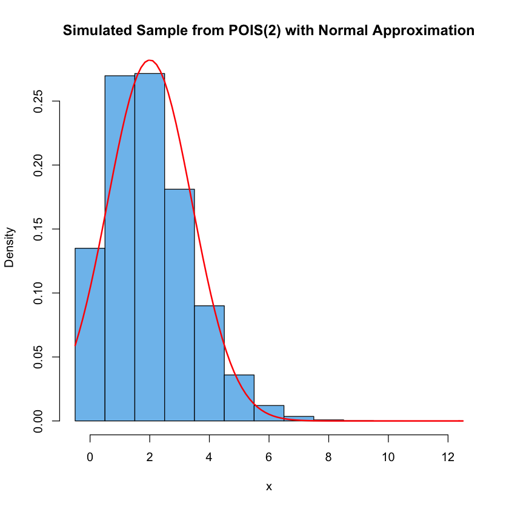

```r
# C)
y = rpois(1000^2, 2);  up=max(y)
hist(y, prob=T, br=(-1:up)+.5, col="skyblue2", xlab="x",
  main="Simulated Sample from POIS(2) with Normal Approximation")
curve(dnorm(x, mean(y), sd(y)), col="red", lwd=2, add=T)

message("First Gen Mean ", mean(y))
message("First Gen Var ", (sd(y))^2)
```

[output not shown]

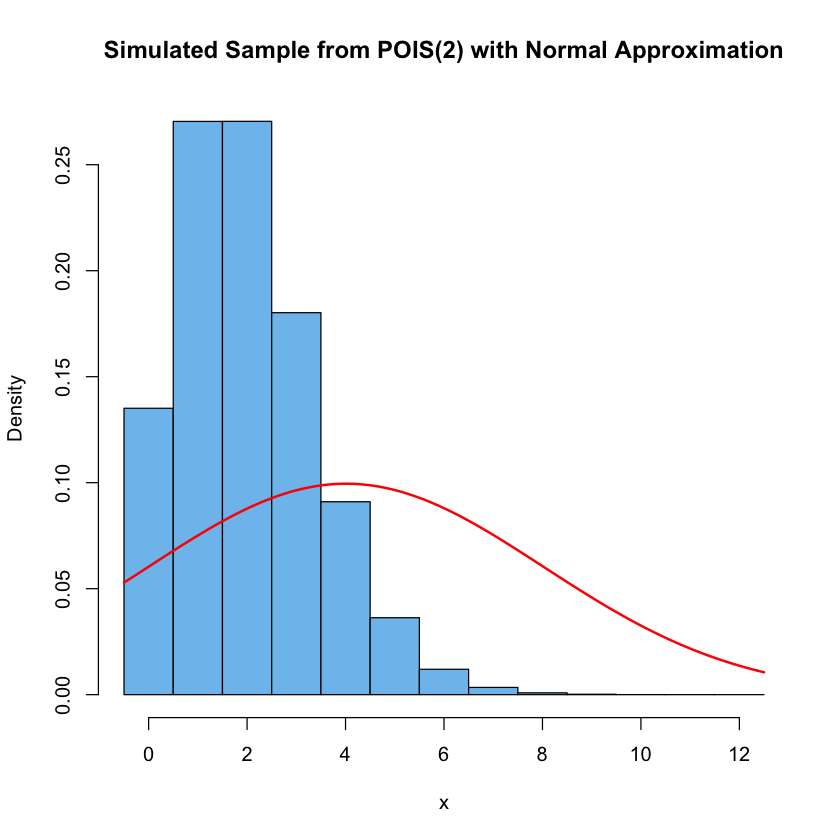

```r
y = rpois(1000^2, 2);  up=max(y)
hist(y, prob=T, br=(-1:up)+.5, col="skyblue2", xlab="x",
  main="Simulated Sample from POIS(2) with Normal Approximation")
curve(dnorm(x, mean(y)^2, sd(y)^2*mean(y)), col="red", lwd=2, add=T)
message("Third Gen Mean ", mean(y)*mean(y)*mean(y))
message("Third Gen Var ", ((sd(y))^2)*((mean(y))^2))
```

```
Third Gen Mean 8.00336047042195

Third Gen Var 8.01100230484604
```

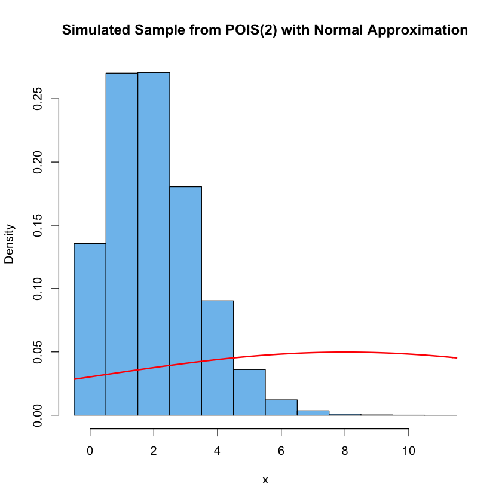

```r
y = rpois(1000^2, 2);  up=max(y)
hist(y, prob=T, br=(-1:up)+.5, col="skyblue2", xlab="x",
  main="Simulated Sample from POIS(2) with Normal Approximation")
curve(dnorm(x, mean(y)^3, sd(y)^2*mean(y)^2), col="red", lwd=2, add=T)
message("Third Gen Mean ", mean(y)*mean(y)*mean(y))
message("Third Gen Var ", ((sd(y))^2)*((mean(y))^2))
```

# 5) Let X1,X2,... be a sequence of independent random variables with E[Xi]=μ and Var(Xi)=σ^2i. Show that if

\begin{equation} n^{-2}\sum_{i=1}^{n} \sigma^2_i \rightarrow 0, \; then \; \bar{X} \rightarrow \mu \; in \; probability. \end{equation}

Using Tchebychev's theorem and Tchebychev's theorem for r.v.s with equal mean we can prove the "Weak law of large numbers"

\begin{equation} When \; V(x_n) \leqslant M \leqslant \infty, \forall n \varepsilon \mathbb{N} \\ \frac{1}{n^2} \sum_{i=1}^{n} Var(X_i) - \frac{1}{n^2} \sum_{i=1}^{n} E[Var(X_i)] \overset{p}{\rightarrow} 0 \end{equation}\begin{equation} If \; E[X_n] = \mu,\forall n \varepsilon \mathbb{N} \\ \frac{1}{n^2} \sum_{i=1}^{n} X_i \overset{p}{\rightarrow} \mu \end{equation}

# 7) Suppose that X1, ..., X20 are independent random variables with density functionsf(x)=3x^2,0≤x≤1. LetS=X1+...+X20.

(a) Use the central limit theorem to approximate P (S ≤ 14).

(b) If you are instead asked to approximate P(S ≤ 15), what simplification can be made to the calculation?

(c) Validate the approximation by plotting the CLT-based density (compute this using dnorm()) and true density of S. Use the inverse CDF method to simulate from the true density and plot using a kernel density estimate (R code plot(kernel()), we’ll learn the details of kernel density estimation later in the course).

a)

\begin{equation} E[X] = \int_{0}^{1} x3x^2dx = 3\int_{0}^{1}x^3dx = 3\frac{x^4}{4} \Big|_0^1 = \frac{3}{4} \\ Var(x) = \int_{0}^{1} x^23x^2dx - (\frac{3}{4})^2 = 3[\frac{x^5}{5}] \Big|_0^1 - (\frac{3}{4})^2 \\ = \frac{3}{5} - (\frac{3}{4})^2 = \frac{3}{80} \\ P(S \leqslant 14) = P(S \leqslant \frac{14}{n}) = P(S \leqslant \frac{14}{20}) = X \sim N(\frac{3}{4},\frac{3}{80}) = 0.3644 \end{equation}

b) \begin{equation} \frac{15}{20} \; is \; \frac{3}{4} \; and \; thus \; is \; just \; E[X]. \end{equation}

# 8) (Based on Rice 5.21) We wish to evaluate the integral... (couldn't copy this problem)

(a) Show that E(I(f)) = I(f)

a) \begin{equation} E[\hat{I}(f)] = E[\frac{1}{n} \sum_{i=1}^{n} f(x_i)/g(x_i)] \\ = \frac{1}{n} \sum_{i=1}^{n} \frac{E[f(x_i]}{E[g(x_i)]} \\ = \frac{1}{n} \sum_{i=1}^{n} \frac{\int_{a}^{b} f(x)dx}{\int_{a}^{b}g(x)dx} \\ \int_{a}^{b}g(x)dx = 1 \\ \frac{1}{n} \sum_{i=1}^{n} \int_{a}^{b} f(x)dx = \int_{a}^{b} f(x)dx \end{equation}